# iSoft: pre-processing and fusion of MS and Raman spectra

iSoft project metting  
07 Dezember, 2023

## MS analyses

```r
msEngine
```

```
MassSpecData
name          NA
author        NA
path          /home/cunha/Documents/github/dataFusion
date          2023-12-07 13:04:32.231652

Analyses:
    type analysis replicate blank polarity spectra features filtered groups
 1:   MS    blank     blank  <NA> positive     186        0        0      0
 2:   MS  cal_050   cal_050  <NA> positive     186        0        0      0
 3:   MS  cal_100   cal_100  <NA> positive     186        0        0      0
 4:   MS  sample1   sample1  <NA> positive     186        0        0      0
 5:   MS  sample2   sample2  <NA> positive     186        0        0      0
 6:   MS  sample3   sample3  <NA> positive     186        0        0      0
```

## Paracetamol extracted ion chromatogram

MS traces were parsed with target mass of 151 Da +/- 1500 ppm.

[interactive chart not shown]

## Spectra of Paracetamol at 100 ng/mL

Spectra was parsed with *m/z* between 100 and 300 Da and an intensity above 20 x 10<sup>6</sup> counts.

[interactive chart not shown]

## Binning approach

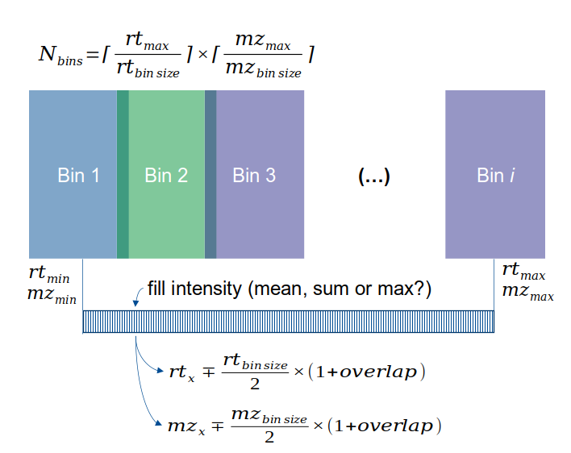

## Binning MS spectra

```r
ms100[1:2, c("rt", "mz", "intensity"), with = FALSE] # MS spectra example
```

```
   rt       mz intensity
1:  0 100.0567  46980000
2:  0 100.9786  65570000
```

```r
bins <- make_bins(ms100, rt_bin_size = 5, mz_bin_size = 2)
nrow(bins)
```

```
[1] 5454
```

```r
bins[500:504, ]
```

```
       rt  mz
20-290 20 290
20-292 20 292
20-294 20 294
20-296 20 296
20-298 20 298
```

## Fill bins

```r
ints100 <- fill_bins(ms100, bins, rt_bin_size = 5, mz_bin_size = 2,
  overlap = 0.1, # a fraction of the bin size
  summaryFunction = "max" # to test mean and sum
)
```

Bins filled with analysis from Paracetamol at 100 ng/ml. The green dot is the bin of Paracetamol (i.e., 40-152).

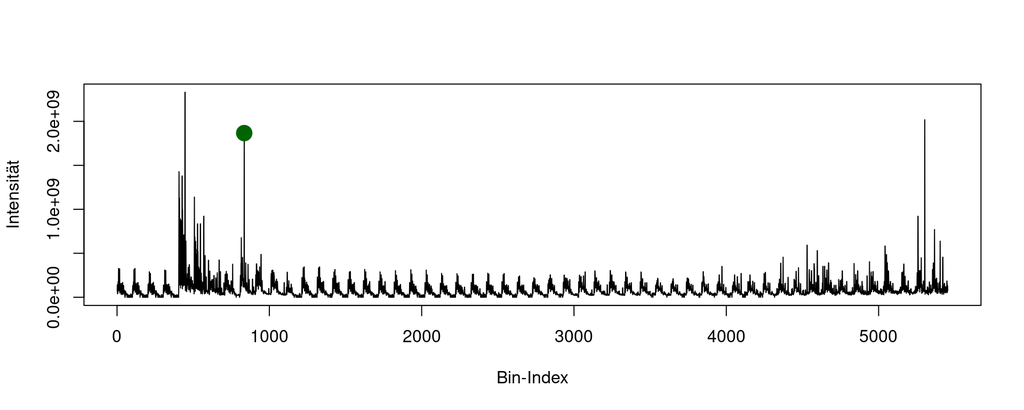

## Blank correction

Bins from analysis of Paracetamol at 100 ng/ml (black) and blank (red). The green dot is the bin correspondent of Paracetamol peak (i.e., 40-152).

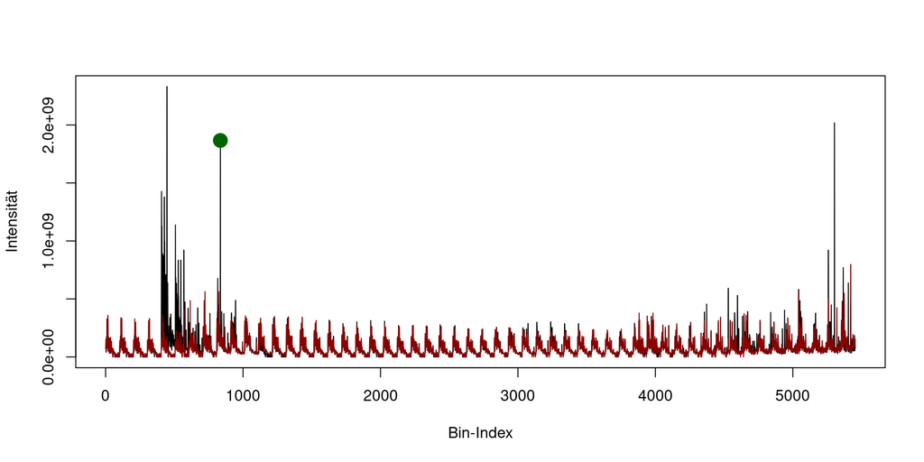

## Blank subtraction

```r
ints100 <- ints100 - intsBlank # Blank subtraction
ints100[ints100 < 0] <- 0 # Zeroing negative values
```

Blank subtracted from bins of analysis from Paracetamol at 100 ng/ml. The green dot is the bin correspondent of Paracetamol peak (i.e., 40-152).

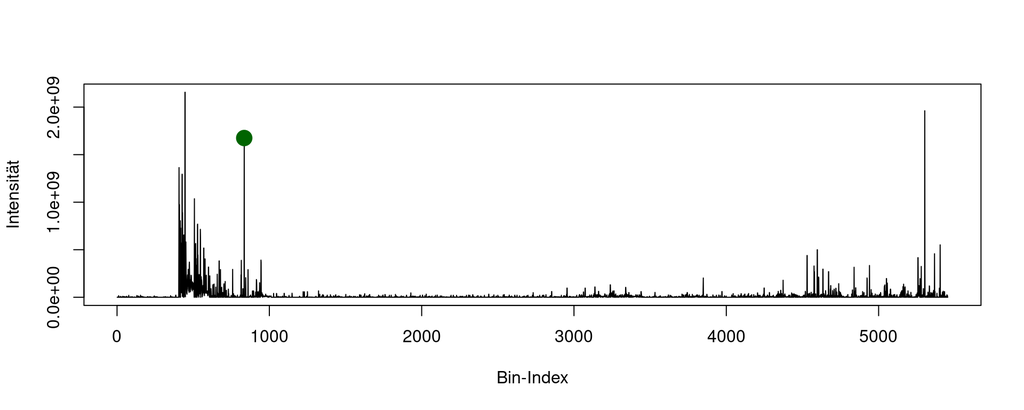

## Scale, mean centering and block weighting

```r
ints100 <- ints100 / sd(ints100) # scale
ints100 <- ints100 / sqrt(length(ints100)) # block weighting
ints100 <- ints100 - mean(ints100) # mean centering
```

Scaled spectra of analysis from Paracetamol at 100 ng/ml. The green dot is the bin correspondent of Paracetamol peak (i.e., 40-152).

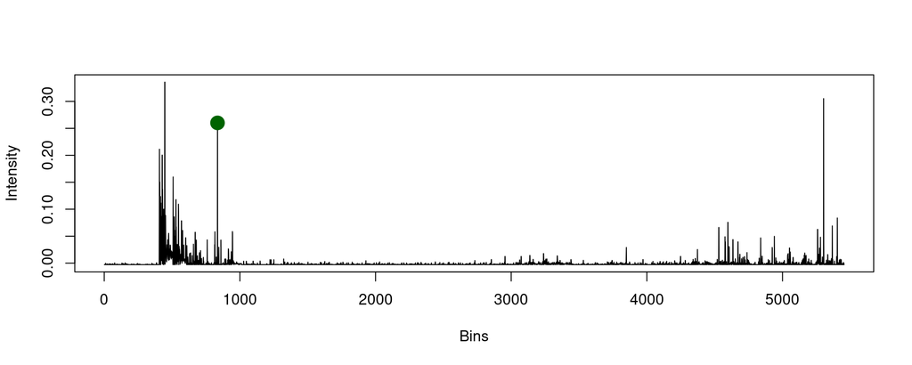

## Wapper function

```r
mzr <- data.table(mzmin = 100, mzmax = 300)
spectra <- msEngine$get_spectra(mz = data.table(mzmin = 100, mzmax = 300), minIntensityMS1 = 20E6)

blankAnalysis <- msEngine$get_analysis_names()[1]

msMat <- prepareMsData(
  spectra,
  rt_bin_size = 5,
  mz_bin_size = 2,
  overlap = 0.1,
  blankAnalysis
)
```

## Pre-processed MS spectra

All MS analyses after bin filling, blank subtraction, scaling, block weighting and mean centering.

[interactive chart not shown]

## Raman

```r
ramanEngine
```

```
RamanData
name          NA
author        NA
path          /home/cunha/Documents/github/dataFusion
date          2023-12-07 13:04:32.91557

Analyses:
                          analysis replicate blank size
 1:        raman_Bevacizumab_11731    Sample Blank 1024
 2:        raman_Bevacizumab_11732    Sample Blank 1024
 3:        raman_Bevacizumab_11733    Sample Blank 1024
 4:        raman_Bevacizumab_11734    Sample Blank 1024
 5:        raman_Bevacizumab_11735    Sample Blank 1024
 6:        raman_Bevacizumab_11736    Sample Blank 1024
 7:        raman_Bevacizumab_11737    Sample Blank 1024
 8:        raman_Bevacizumab_11738    Sample Blank 1024
 9:        raman_Bevacizumab_11739    Sample Blank 1024
 10:       raman_Bevacizumab_11740    Sample Blank 1024
 11:       raman_Bevacizumab_11741    Sample Blank 1024
 12: raman_blank_Bevacizumab_10005     Blank Blank 1024
 13: raman_blank_Bevacizumab_10006     Blank Blank 1024
 14: raman_blank_Bevacizumab_10007     Blank Blank 1024
 15: raman_blank_Bevacizumab_10008     Blank Blank 1024
 16: raman_blank_Bevacizumab_10009     Blank Blank 1024
 17: raman_blank_Bevacizumab_10010     Blank Blank 1024
 18: raman_blank_Bevacizumab_10011     Blank Blank 1024
 19: raman_blank_Bevacizumab_10012     Blank Blank 1024
 20: raman_blank_Bevacizumab_10013     Blank Blank 1024
 21: raman_blank_Bevacizumab_10014     Blank Blank 1024
 22: raman_blank_Bevacizumab_10015     Blank Blank 1024
```

## Raman spectra

[interactive chart not shown]

## Average spectra

Averaged spectra for the Sample (black) and Blank (red).

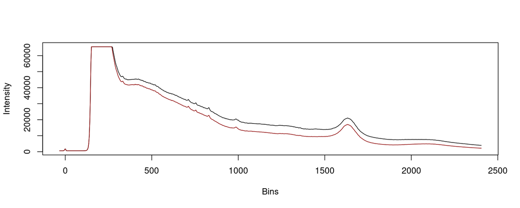

## Average effect

[interactive chart not shown]

## Trimming and blank subtraction

```r
sampleSpectraAv <- sampleSpectraAv[sampleSpectraAv$shift > 330]
blankSpectraAv <- blankSpectraAv[blankSpectraAv$shift > 330]
sampleSpectraAv$intensity <- sampleSpectraAv$intensity - blankSpectraAv$intensity
```

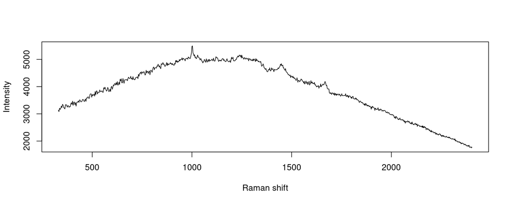

## Baseline correction

```r
baselineCorrection <- function(spectra, lambda = 5, p = 0.05, maxit = 10) {
  mat <- matrix(as.numeric(spectra$intensity), nrow = 1, dimnames = list(1, spectra$shift))
  # Do own baseline correction for better control
  baseOut <- baseline::baseline.als(mat, lambda = lambda, p = p, maxit = maxit)
  data.table(
    "shift" = spectra$shift,
    "original" = spectra$intensity,
    "baseline" = baseOut$baseline[1, ],
    "corrected" = baseOut$corrected[1, ]
  )
}
```

## Baseline corrected

Baseline (red) correction for the Sample spectrum (black) with corrected spectrum colored green.

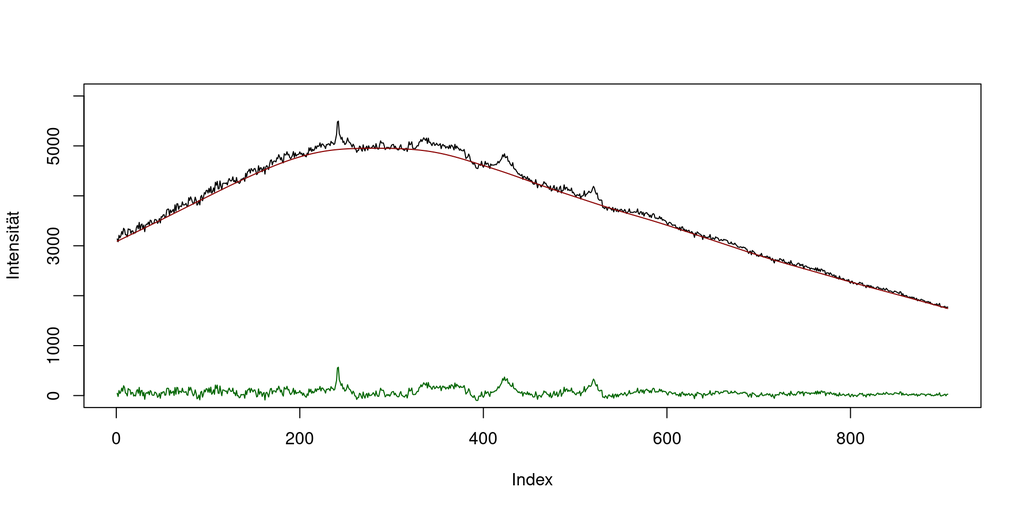

## Scale, mean centering and block weighting

```r
ramanSpectra <- sampleSpectraCorr$corrected
ramanSpectra <- ramanSpectra / sd(ramanSpectra) # scale
ramanSpectra <- ramanSpectra / sqrt(length(ramanSpectra)) # block weighting
ramanSpectra <- ramanSpectra - mean(ramanSpectra) # mean centering
#ramanSpectra <- ramanSpectra + abs(min(ramanSpectra)) # lift base
```

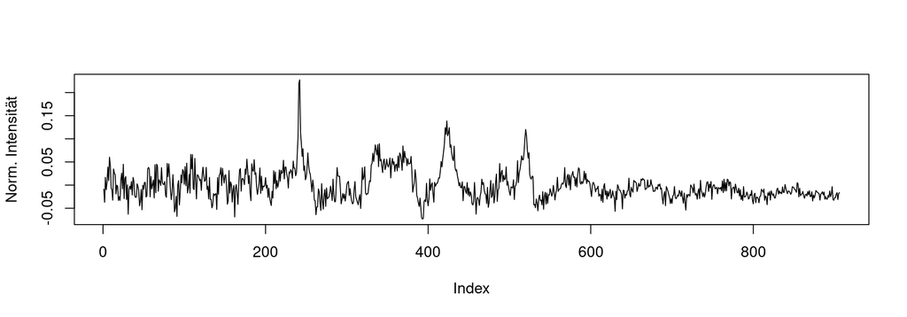

## Warpper function

To be done …

## Data fusion

```r
ramanMat <- matrix(ramanSpectra, nrow = 1, dimnames = list(1, sampleSpectraCorr$shift))

# For now we repeat the raman dataset for each MS analysis
for (i in seq_len(nrow(msMat) - 1)) {
  ramanMat <- rbind(ramanMat, ramanMat[1, , drop = FALSE])
}
rownames(ramanMat) <- rownames(msMat)

fusedMat <- cbind(msMat, ramanMat)
```

## Merged data

[interactive chart not shown]

## Statistic analysis

[interactive chart not shown]

## Assessing loadings

[interactive chart not shown]

## Future work

- Add retention time alignment for MS spectra (Sandeep, on going)
- Finish the wrapper functions to automate the pre-processing workflow for MS and integrate in StreamFind (Ricardo)
- Finish the wrapper functions to automate the pre-processing workflow for Raman and integrate in StreamFind (Sandeep, meeting to introduce into StreamFind)
- Evaluate the effected of mean, max and sum for MS and Raman spectra (Sandeep, only after integration into StreamFind and new Paracetamol data for MS and Raman is available)
- Test the workflow for the other substances (Ricardo)
- Integrate quantification (Not yet)
- Study approaches for statistic analysis (Sandeep, create repository iSoftML to start explore Machine learning approaches)

Thank you for your attention